# Projekt 1-porządkowanie liniowe, analiza skupień oraz skalowanie wielowymiarowe

Anna Pietryka

13 12 2021

W społeczeństwie można zaobserwować coraz większą świadomość dotyczącą jakości oraz składu spożywanych produktów. Wiele osób sprawdza etykiety robiąc zakupy w supermarkecie. Natomiast gdy kupujemy gotowe posiłki często zapominamy o tym, aby również i one miały dobre składy. W projekcie zostaną przeanalizowane składy produktów znajdujących się w menu kawiarni Starbucks. W rankingu zostaną wyłonione produkty o najlepszym składzie, a za pomocą grupowania zostaną wyodrębnione grupy produktów o podobnym składzie i kaloryczności.

Celem pracy jest zastosowanie wybranych metod porządkowania liniowego, analizy skupień oraz skalowania wielowymiarowego. Za pomocą wybranych technik zostaną udzielone odpowiedzi na następujące pytania:

*Jakie produkty z menu Starbucks są najzdrowsze, a które najmniej zdrowe?*

*Czy wśród oferowanych produktów można wyróżnić grupy produktów charakteryzujące się podobnym składem i kalorycznością?*

## Opis i wstępna analiza wykorzystywanych danych

Zestaw danych o nazwie *„starbacs_food”* dotyczy zawartości odżywczej produktów sprzedawanych w kawiarni Starbucks. Dane pochodzą ze strony Kaggle.com. Zbiór został przekształcony do zbioru „starbucks_food_customized” poprzez przelicznie procentowej zawartości danych składników odżywczych w produktach, aby uzyskać porównywalne wartości (inaczej można interpretować wartości jako: ile gram danego składnika zawiera się w 100 gramach produktu). Zbiór danych składa się z następujących zmiennych:  
*Calories* - zawartość kalorii w produkcie [Kcal]  
*Fat* - procentowa zawartość tłuszczu w produkcie  
*Carbohydrate* - procentowa zawartość węglowodanów w produkcie  
*Fiber* - procentowa zawartość błonnika w produkcie  
*Protein* - procentowa zawartość białka w produkcie  
*Sodium* - procentowa zawartość sody w produkcie  
*Sugars* - procentowa zawartość cukru w produkcie

### Braki danych i wartości odstające

#### Wykresy pudełkowe dla analizowanych zmiennych:

W danych nie zaobserwowano wartości brakujących. Na zestawieniu wykresów pudełkowych poszczególnych zmiennych można zaobserwować wartości odstające.

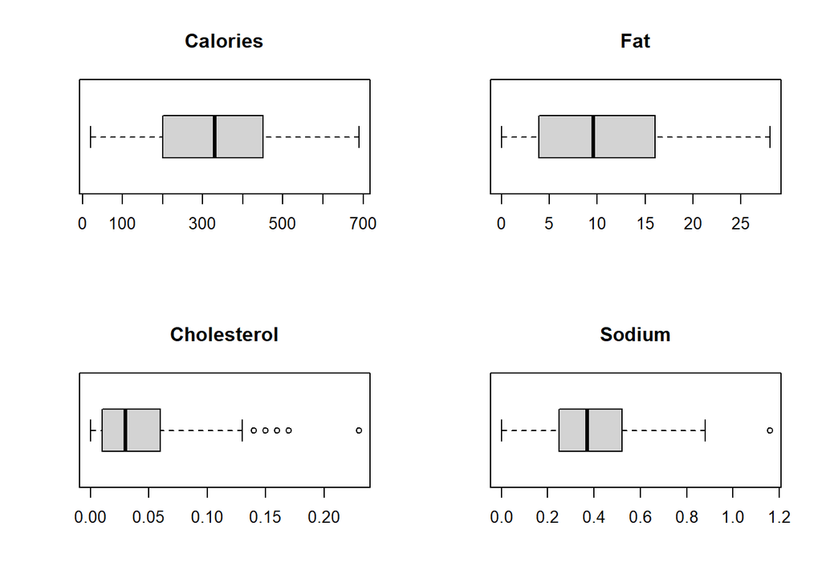

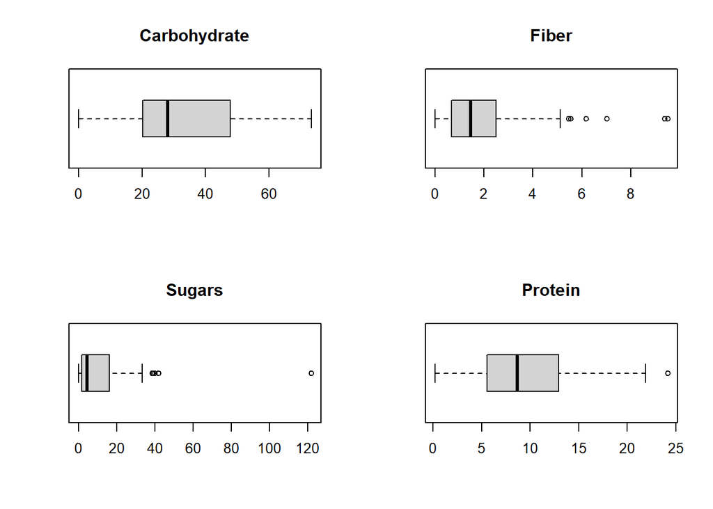

Obserwacje oddające można zaobserwować dla zmiennych *Cholesterol*, *Sodium*, *Fiber*, *Sugar* i *Protein* zarówno na wykresie pudełkowym jak i w długich ogonach krzywych gęstości. Obserwacje nie zostały usunięte, aby zachować różnorodność składu produktów.

#### Wykresy gęstości dla analizowanych zmiennych:

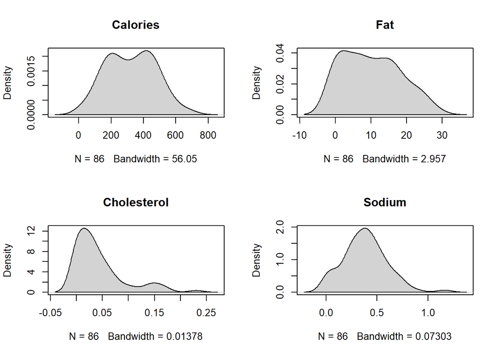

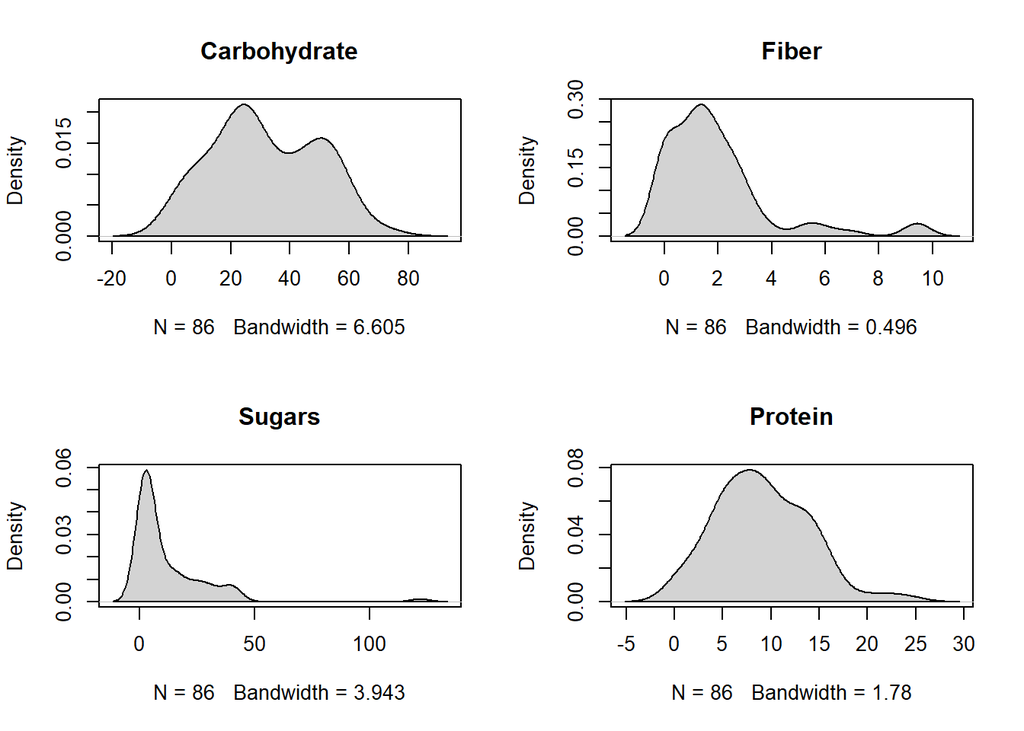

Na wykresie gęstości dla zmiennej *Calories* można zaobserwować, że największa ilość produktów posiada wartość kaloryczną na poziomie około 200 Kcal i 400 Kcal.

Na wykresie gęstości dla zmiennej *Sugars* można zaobserwować, że produkty w menu Starbucks nie zawieraj dużej procentowej ilości cukru. W ofercie znajdują się pojedyncze produkty, w których zawartość cukru jest wysoka.

### Podstawowe statystyki:

Odchylenie standardowe

```
##     Calories          Fat  Cholesterol       Sodium Carbohydrate        Fiber
## 151.79370991   8.00885344   0.04867829   0.21410243  17.88802594   2.05279890
##       Sugars      Protein
##  16.99428727   4.81994361
```

```
##     Calories          Fat          Cholesterol          Sodium
##  Min.   : 20.0   Min.   : 0.000   Min.   :0.00000   Min.   :0.0000
##  1st Qu.:200.0   1st Qu.: 3.955   1st Qu.:0.01000   1st Qu.:0.2500
##  Median :330.0   Median : 9.590   Median :0.03000   Median :0.3700
##  Mean   :323.4   Mean   :10.192   Mean   :0.04302   Mean   :0.3824
##  3rd Qu.:447.5   3rd Qu.:16.012   3rd Qu.:0.06000   3rd Qu.:0.5150
##  Max.   :690.0   Max.   :28.050   Max.   :0.23000   Max.   :1.1600
##   Carbohydrate       Fiber           Sugars           Protein
##  Min.   : 0.00   Min.   :0.000   Min.   :  0.000   Min.   : 0.200
##  1st Qu.:20.22   1st Qu.:0.700   1st Qu.:  1.843   1st Qu.: 5.570
##  Median :28.13   Median :1.465   Median :  4.470   Median : 8.695
##  Mean   :31.80   Mean   :1.914   Mean   : 11.638   Mean   : 9.110
##  3rd Qu.:47.71   3rd Qu.:2.500   3rd Qu.: 16.150   3rd Qu.:12.865
##  Max.   :73.33   Max.   :9.520   Max.   :121.860   Max.   :24.190
```

Wartość średniej i mediany dla **zawartości kalorycznej** produktów nie różnią się istotnie. Średnia zawartość kalorii wynosi 323 Kcal, a wartość mediany 330 Kcal. Występuje duża różnica pomiędzy minimalną, a maksymalną zawartością kalorii w oferowanych produktach. Wartość najmniejsza wynosi 20 Kcal, a wartość największa aż 690 Kcal.

Średnia zawartość **tłuszczu** w produktach znajdujcych się w ofercie Starbucks wynosi 10 gram na 100 gram produktu. W ofercie znajdują się również produkty nie zawierające tłuszczu.

Średnia wartość zmiennej **Cholesterol** wynosi 0,043 gram na 100 gram produktu. Na postawie wartości maksymalnej oraz wartości górnego kwartla można zaobserwować, że występują pojedyncze produkty, dla których zawartość cholesterolu jest znacznie wyższa niż w większości produktów.

Średnia zawartość **sody** w produktach wynosi 382,4 mg/100 g produktu. Mniej więcej taką samą zawartość sodu można znaleźć w serku twarogowym. Wartość maksymalna dla zawartości sodu wynosi 1160 mg/100 g produktu. Może być to spowodowane tym, że składnikami produktu są szynka, ser lub łosoś.

Średnia i mediana zawartości **węglowodanów** w produktach wynosi kolejno 31,8 gram i 28,13 gramy na 100 gram produktu. Statystki te przyjmują zbliżone wartości. W ofercie produktów znajdują się produkty o bardzo małej, jak i takie o dużej zawartości węglowodanów.

Średnia zawartość **błonnika** w produktach wynosi około 2 g/100 g produktu. Większa cześć produktów nie zawiera dużych ilości błonnika. Na podstawie wartości górnego kwartyla i wartości maksymalnej można stwierdzić, że w ofercie znajduje się kilka produktów o znacznie większej zawartości błonnika niż pozostałe produkty.

Średnia zawartość **białka** w sprzedawanych produktach wynosi 9,11 g/100 g produktu. Na podstawie wartości górnego kwartyla i wartości maksymalnej można zauważyć, że ofercie znajduje się kilka produktów o znacznie większej zawartości biała niż pozostałe produkty. Obserwację tą można uzasadnić tym, że w ofercie znajdują się produkty zawierające jajka lub sery.

#### Współczynnik zmienności:

Współczynnik zmienności jest stosowany w statystyce jako parametry mierzący zróżnicowanie cechy. Współczynnik zmienności dla zmiennych wykorzystywanych w analizie nie powinien przyjmować wartości mniejszych od 10%.

```
##     Calories          Fat  Cholesterol       Sodium Carbohydrate        Fiber
##    0.4693244    0.7857729    1.1314413    0.5598300    0.5624754    1.0727393
##       Sugars      Protein
##    1.4601945    0.5290692
```

Na podstawie powyższego listingu można zauważyć, że wartość współczynnika jest większa od 10% dla wszystkich analizowanych cech.

#### Macierz korelacji:

Zmienne wykorzystane do badanie nie powinny charakteryzować się zbyt dużym współczynnikiem korelacji. Za odpowiednią wartość współczynnika korelacji uznaje się wartość poniżej |0,9|.

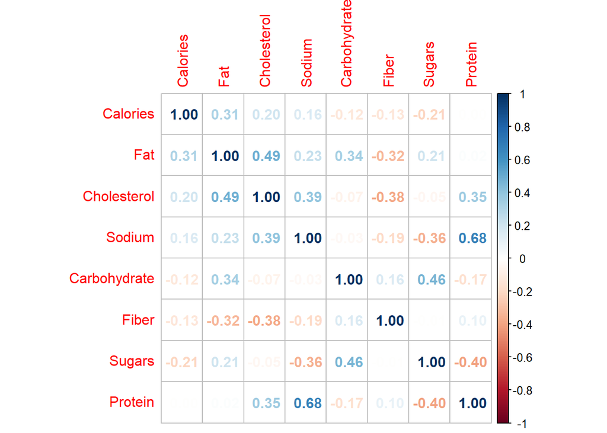

Na podstawie powyższej macierzy korelacji można zaobserwować, że współczynnik korelacji dal każdej pary zmiennych przyjmuje wartości mniejsze od |0,9|.

## Porządkowanie liniowe

### Metoda Hellwiga (wzorzec i antywzorzec)

#### Określenie charakteru analizowanych zmiennych diagnostycznych:

*Calories* - nominanta (posiłki muszą zawierać optymalną ilość kalorii, aby zapewnić odpowiedni poziom zapotrzebowania energetycznego organizmu)  
*Fat* - destymulanta (posiłki zawierające dużą ilość tłuszczy negatywnie wpływają na stan zdrowia)  
*Carbohydrate* - nominata (węglowodany dostarczają organizmowi energii i powinniśmy je spożywać odpowiednich ilościach)  
*Fiber* - stymulanta (wysoka zawartość błonnika w diecie jest konieczna do prawidłowego funkcjonowania jelit)  
*Protein* - nominata (do prawidłowego funkcjonowania organizmu jest potrzebna optymalna ilość białka)  
*Sodium* - destymulanta (dzienne zapotrzebowanie sody dla organizmu w zupełności zapewnia sól kuchenna. Raczej jako społeczeństwo mamy tendencję do nadużywania soli, więc w produktach gotowych powinno być jej jak najmniej)  
*Sugars* - destymulanta (cukier podobnie jak sól powinien być ograniczany w codziennej diecie ponieważ jego duże ilości niekorzystnie wpływają na organizm)

Za produkty, które są dobrym źródłem błonnika uważane są takie produkty, które zawierają 3g błonnika na 100g produktu. W związku z tym do obliczeń, jako wartość optymalna dla zmiennej *Fiber* zostanie zastosowana wartość 3.

#### Ranking (fragment):

```
##                               Hellwig
## Cinnamon Raisin Bagel       0.6120238
## Berry Trio Parfait          0.6080770
## Everything Bagel            0.6027044
## 8-Grain Roll                0.6022848
## Lemon Crunch Yogurt Parfait 0.5972922
## Tomato & Mozzarella         0.5963937
```

Najwyższą pozycje w rankingu zajmuje bajgiel z rodzynkami i cynamonem. Bajgiel ma zawartość błonnika na poziomie 3,03g/100g produktu. Jest to zawartość zbliżona do wartości ustalonej jako optymalna. Ale nie wszystkie produkty z najwyższych miejsc rankingu zawierają poziom błonnika bliski wartości optymalnej. Największym zaskoczeniem jest pojawienie się na tak wysokiej pozycji jogurtu z cytryną i chrupiącymi płatkami ponieważ ma on stosunkowo wysoką zawartość cukru i niską zawartość błonnika. Można podejrzewać, że wynik ten został uzyskany na podstawie niskiej kaloryczności, niskiej zwartości cholesterolu, sody i tłuszczu.

```
##                             Calories  Fat Cholesterol Sodium Carbohydrate Fiber
## 8-Grain Roll                     340 3.94        0.00   0.34        53.54  3.15
## Cinnamon Raisin Bagel            270 1.01        0.00   0.37        58.59  3.03
## Everything Bagel                 290 4.00        0.01   0.45        53.00  3.00
## Tomato & Mozzarella              120 0.00        0.01   0.40        28.97  2.07
## Berry Trio Parfait                20 0.00        0.00   0.08        23.78  1.83
## Lemon Crunch Yogurt Parfait      110 0.00        0.04   0.06        25.93  0.62
##                             Sugars Protein
## 8-Grain Roll                 11.81    7.09
## Cinnamon Raisin Bagel        11.11    9.09
## Everything Bagel              5.00   11.00
## Tomato & Mozzarella           1.38   10.34
## Berry Trio Parfait           15.85    8.54
## Lemon Crunch Yogurt Parfait  17.90    8.64
```

#### Grupowanie według średniej:

Najwyższy poziom:

```
##                                                                     Hellwig
## Cinnamon Raisin Bagel                                             0.6120238
## Berry Trio Parfait                                                0.6080770
## Everything Bagel                                                  0.6027044
## 8-Grain Roll                                                      0.6022848
## Lemon Crunch Yogurt Parfait                                       0.5972922
## Tomato & Mozzarella                                               0.5963937
## Mango & Coconut Yogurt Bowl                                       0.5960735
## Chonga Bagel                                                      0.5910433
## Fresh Blueberries and Honey Greek Yogurt Parfait                  0.5907173
## Baja Black Bean Veggie Wrap                                       0.5809730
## Strawberry & Toasted Almonds Overnight Grains                     0.5807883
## Chicken Caprese                                                   0.5790156
## Reduced-Fat Turkey Bacon & Cage Free Egg White Breakfast Sandwich 0.5774045
## Hearty Blueberry Oatmeal                                          0.5770320
```

Poziom ponadprzeciętny:

```
##                                                      Hellwig
## Chicken & Fig Spread                               0.5592536
## Seasoned Turkey & Green Pepper Pico                0.5588512
## Classic Oatmeal                                    0.5578445
## Justin's Classic Almond Butter                     0.5523939
## Spinach, Feta & Cage Free Egg White Breakfast Wrap 0.5513941
## Plain Bagel                                        0.5511077
## Chicken Wrap Protein Box                           0.5510995
## Roasted Carrot & Kale Side Salad                   0.5490974
## The Classic - Bantam Bagels (2 Pack)               0.5453405
## Lentils & Vegetable Protein Bowl with Brown Rice   0.5451437
## Cage-Free Eggs & Seasoned Grains Side Salad        0.5438180
## Everybody's Favorite - Bantam Bagel (2 Pack)       0.5413805
## Crispy Grilled Cheese Sandwich                     0.5412067
## Sprouted Grain Vegan Bagel                         0.5390020
## Chipotle Chicken Wrap                              0.5388018
## Almond Croissant                                   0.5370285
## Turkey Pesto Panini                                0.5361385
## Za'atar Chicken & Lemon Tahini                     0.5359615
## Justin's Chocolate Hazelnut Butter                 0.5352055
## Roasted Turkey & Dill Havarti                      0.5336545
## Sous Vide Egg Bites: Egg White & Red Pepper        0.5313568
## Blueberry Scone                                    0.5287515
## Smoked Turkey Protein Box                          0.5279776
## Classic Coffee Cake                                0.5266547
## Chicken BLT Protein Box                            0.5257448
## Eggs & Cheese Protein Box                          0.5236643
## Farmers' Market Protein Box                        0.5233577
## Petite Vanilla Bean Scone                          0.5193993
## Double Chocolate Chunk Brownie                     0.5188474
## Sous Vide Egg Bites: Ham, Cheddar & Peppers        0.5180833
## PB&J Protein Box                                   0.5178197
## French Toast - Bantam Bagels (2 Pack)              0.5165160
```

Poziom poniżej przeciętnej:

```
##                                                         Hellwig
## Turkey Pastrami Reuben                                0.5141287
## Banana Nut Bread                                      0.5118436
## Cauliflower Tabbouleh Side Salad                      0.5118373
## Chocolate Croissant                                   0.5115861
## Grilled Chicken & Cauliflower Tabbouleh               0.5088320
## Blueberry Muffin                                      0.5075406
## Chicken & Double-Smoked Bacon                         0.5058160
## Ham & Cheese Croissant                                0.5050073
## Garden Greens & Shaved Parmesan Side Salad            0.5012683
## Honey BBQ Sriracha Chicken                            0.5010639
## Blueberry Oat Cake                                    0.4993626
## Chocolate Cake Pop                                    0.4989896
## Cheese Danish                                         0.4983355
## Avocado Spread                                        0.4959575
## Iced Lemon Loaf Cake                                  0.4940173
## Chocolate Chip Cookie                                 0.4932447
## Pumpkin Bread                                         0.4924544
## Ham & Swiss Panini                                    0.4881579
## Sous Vide Egg Bites: Chicken Chorizo Tortilla         0.4870755
## Smoked Mozzarella & Roasted Peppers                   0.4839969
## Smoked Pork Cubano                                    0.4827128
## Butter Croissant                                      0.4806228
## Roasted Ham, Swiss & Egg Breakfast Sandwich           0.4787951
## Spicy Chorizo, Monterey Jack & Egg Breakfast Sandwich 0.4772898
## Sausage, Cheddar & Egg Breakfast Sandwich             0.4731531
## Smoked Shoulder Bacon Breakfast Sandwich              0.4697741
## Strawberry Cake Pop                                   0.4696798
## Morning Bun                                           0.4689257
## Bacon, Gouda & Egg Breakfast Sandwich                 0.4681465
## Chocolate Chip Cookie Dough Cake Pop                  0.4622029
## Frosted Doughnut Cake Pop                             0.4618462
## Sous Vide Egg Bites: Bacon & Gruyere                  0.4605647
## Gluten-Free Marshmallow Dream Bar                     0.4587893
```

Poziom najniższy:

```
##                                                  Hellwig
## Confetti Sugar Cookie                          0.4427612
## Old-Fashioned Glazed Doughnut                  0.4421265
## Double-Smoked Bacon, Cheddar & Egg Sandwich    0.4318670
## Birthday Cake Pop                              0.4290249
## Chicken Sausage & Bacon Biscuit                0.3943012
## Vegan Superberry Acai                          0.2585555
## Creminelli Sopressata Monterey Jack Snack Tray 0.2506750
```

## Analiza skupień

### Metoda grupowania podziałowego

Metoda k-średnich nie daje zbyt dobrych wyników, gdy zbiór danych zawiera obserwacje odstające. W związku z tym na listingu z podstawowymi statystkami dla standaryzowanych danych można zobaczyć, że w zbiorze znajdują się obserwację odległe od średniej więcej niż trzy odchylenia standardowe. Obserwacje te zostaną usunięte.

```
##     Calories             Fat            Cholesterol          Sodium
##  Min.   :-1.99896   Min.   :-1.27263   Min.   :-0.8838   Min.   :-1.78626
##  1st Qu.:-0.81314   1st Qu.:-0.77880   1st Qu.:-0.6784   1st Qu.:-0.61859
##  Median : 0.04328   Median :-0.07521   Median :-0.2675   Median :-0.05811
##  Mean   : 0.00000   Mean   : 0.00000   Mean   : 0.0000   Mean   : 0.00000
##  3rd Qu.: 0.81736   3rd Qu.: 0.72672   3rd Qu.: 0.3488   3rd Qu.: 0.61913
##  Max.   : 2.41492   Max.   : 2.22974   Max.   : 3.8411   Max.   : 3.63171
##   Carbohydrate         Fiber             Sugars           Protein
##  Min.   :-1.7779   Min.   :-0.9322   Min.   :-0.6848   Min.   :-1.84862
##  1st Qu.:-0.6475   1st Qu.:-0.5912   1st Qu.:-0.5764   1st Qu.:-0.73450
##  Median :-0.2053   Median :-0.2185   Median :-0.4218   Median :-0.08615
##  Mean   : 0.0000   Mean   : 0.0000   Mean   : 0.0000   Mean   : 0.00000
##  3rd Qu.: 0.8893   3rd Qu.: 0.2857   3rd Qu.: 0.2655   3rd Qu.: 0.77901
##  Max.   : 2.3215   Max.   : 3.7054   Max.   : 6.4858   Max.   : 3.12862
```

#### Eksperymentalny podział na grupy

**Podział zbioru na 2 grupy:**

Porównywanie statystyk w grupach (dla k = 2)

```
##
##  Descriptive statistics by group
## group: 1
##              vars  n   mean     sd median trimmed    mad   min    max  range
## Calories        1 58 336.64 164.54 325.00  337.08 192.74 20.00 690.00 670.00
## Fat             2 58   7.21   6.03   6.11    6.89   8.03  0.00  19.59  19.59
## Cholesterol     3 58   0.04   0.05   0.02    0.03   0.03  0.00   0.17   0.17
## Sodium          4 58   0.41   0.21   0.43    0.42   0.20  0.01   0.88   0.87
## Carbohydrate    5 58  24.58  14.22  23.82   23.87  12.77  0.56  58.59  58.03
## Fiber           6 58   1.74   1.55   1.46    1.53   1.34  0.00   7.02   7.02
## Sugars          7 58   4.28   4.25   2.70    3.54   2.23  0.00  17.90  17.90
## Protein         8 58   9.86   4.47   9.75   10.09   5.06  0.20  19.70  19.50
##               skew kurtosis    se
## Calories      0.02    -0.92 21.61
## Fat           0.33    -1.20  0.79
## Cholesterol   1.55     1.16  0.01
## Sodium       -0.25    -0.55  0.03
## Carbohydrate  0.41    -0.38  1.87
## Fiber         1.32     1.95  0.20
## Sugars        1.70     2.15  0.56
## Protein      -0.31    -0.44  0.59
## ------------------------------------------------------------
## group: 2
##              vars  n   mean     sd median trimmed   mad    min    max  range
## Calories        1 22 325.00 110.57 360.00  328.89 88.96 120.00 480.00 360.00
## Fat             2 22  18.81   5.37  19.06   19.05  6.65   8.33  28.05  19.72
## Cholesterol     3 22   0.05   0.03   0.05    0.05  0.03   0.00   0.17   0.17
## Sodium          4 22   0.31   0.10   0.29    0.31  0.10   0.17   0.52   0.35
## Carbohydrate    5 22  51.85   7.60  53.49   51.45  7.24  39.45  73.33  33.88
## Fiber           6 22   1.35   1.31   1.14    1.18  1.48   0.00   5.47   5.47
## Sugars          7 22  27.42  10.29  27.30   27.68 14.14   8.06  41.86  33.80
## Protein         8 22   5.81   2.29   5.07    5.77  1.42   1.67  10.10   8.43
##               skew kurtosis    se
## Calories     -0.48    -1.24 23.57
## Fat          -0.30    -1.04  1.15
## Cholesterol   1.54     3.60  0.01
## Sodium        0.53    -0.83  0.02
## Carbohydrate  0.63     0.79  1.62
## Fiber         1.29     1.97  0.28
## Sugars       -0.16    -1.25  2.19
## Protein       0.38    -0.73  0.49
```

Wykres podziału zbioru na 2 grupy

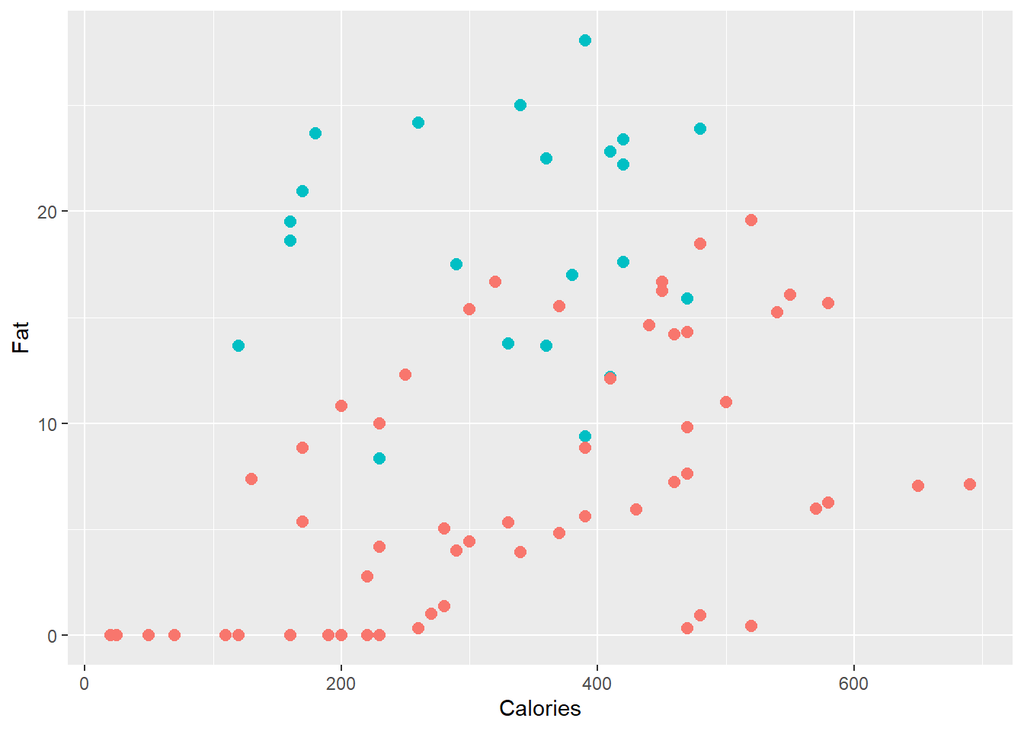

**Podział zbioru na 3 grupy:**

Porównywanie statystyk w grupach (dla k = 3)

```
##
##  Descriptive statistics by group
## group: 1
##              vars  n   mean     sd median trimmed   mad    min    max  range
## Calories        1 22 325.00 110.57 360.00  328.89 88.96 120.00 480.00 360.00
## Fat             2 22  18.81   5.37  19.06   19.05  6.65   8.33  28.05  19.72
## Cholesterol     3 22   0.05   0.03   0.05    0.05  0.03   0.00   0.17   0.17
## Sodium          4 22   0.31   0.10   0.29    0.31  0.10   0.17   0.52   0.35
## Carbohydrate    5 22  51.85   7.60  53.49   51.45  7.24  39.45  73.33  33.88
## Fiber           6 22   1.35   1.31   1.14    1.18  1.48   0.00   5.47   5.47
## Sugars          7 22  27.42  10.29  27.30   27.68 14.14   8.06  41.86  33.80
## Protein         8 22   5.81   2.29   5.07    5.77  1.42   1.67  10.10   8.43
##               skew kurtosis    se
## Calories     -0.48    -1.24 23.57
## Fat          -0.30    -1.04  1.15
## Cholesterol   1.54     3.60  0.01
## Sodium        0.53    -0.83  0.02
## Carbohydrate  0.63     0.79  1.62
## Fiber         1.29     1.97  0.28
## Sugars       -0.16    -1.25  2.19
## Protein       0.38    -0.73  0.49
## ------------------------------------------------------------
## group: 2
##              vars  n   mean     sd median trimmed    mad   min    max  range
## Calories        1 37 306.08 177.38 280.00  300.32 192.74 20.00 690.00 670.00
## Fat             2 37   4.83   4.14   5.03    4.56   5.66  0.00  14.61  14.61
## Cholesterol     3 37   0.01   0.01   0.01    0.01   0.01  0.00   0.04   0.04
## Sodium          4 37   0.30   0.17   0.37    0.31   0.13  0.01   0.57   0.56
## Carbohydrate    5 37  24.21  16.67  22.09   23.46  18.22  0.56  58.59  58.03
## Fiber           6 37   2.06   1.70   1.82    1.85   1.04  0.00   7.02   7.02
## Sugars          7 37   4.96   4.97   2.72    4.29   2.18  0.00  17.90  17.90
## Protein         8 37   7.42   3.52   8.11    7.50   2.80  0.20  15.00  14.80
##               skew kurtosis    se
## Calories      0.30    -0.87 29.16
## Fat           0.40    -0.90  0.68
## Cholesterol   0.73    -0.62  0.00
## Sodium       -0.53    -1.12  0.03
## Carbohydrate  0.49    -0.90  2.74
## Fiber         1.18     1.05  0.28
## Sugars        1.31     0.43  0.82
## Protein      -0.39    -0.11  0.58
## ------------------------------------------------------------
## group: 3
##              vars  n   mean     sd median trimmed    mad    min    max  range
## Calories        1 21 390.48 125.52 450.00  391.76 133.43 190.00 580.00 390.00
## Fat             2 21  11.41   6.61  14.29   11.86   3.53   0.00  19.59  19.59
## Cholesterol     3 21   0.08   0.05   0.06    0.08   0.04   0.03   0.17   0.14
## Sodium          4 21   0.61   0.12   0.59    0.61   0.10   0.35   0.88   0.53
## Carbohydrate    5 21  25.24   8.66  26.54   25.75   7.24   6.92  42.86  35.94
## Fiber           6 21   1.18   1.06   0.98    1.10   1.45   0.00   3.25   3.25
## Sugars          7 21   3.10   2.15   2.02    2.89   1.42   0.70   8.33   7.63
## Protein         8 21  14.17   2.03  13.73   14.10   1.32  10.33  19.70   9.37
##               skew kurtosis    se
## Calories     -0.18    -1.54 27.39
## Fat          -0.73    -1.04  1.44
## Cholesterol   0.37    -1.66  0.01
## Sodium        0.03    -0.38  0.03
## Carbohydrate -0.53     0.02  1.89
## Fiber         0.45    -1.17  0.23
## Sugars        0.75    -0.65  0.47
## Protein       0.58     0.73  0.44
```

Wykres podziału zbioru na 3 grupy

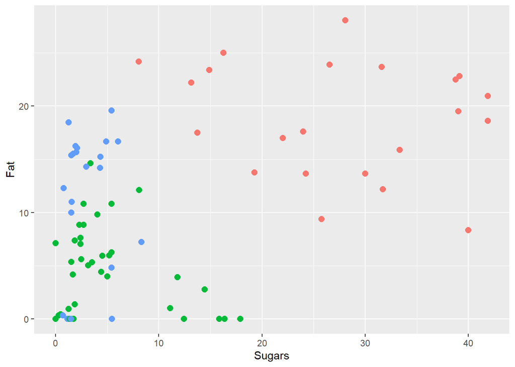

#### Wybór optymalnej liczby grup za pomocą “metody łokcia”

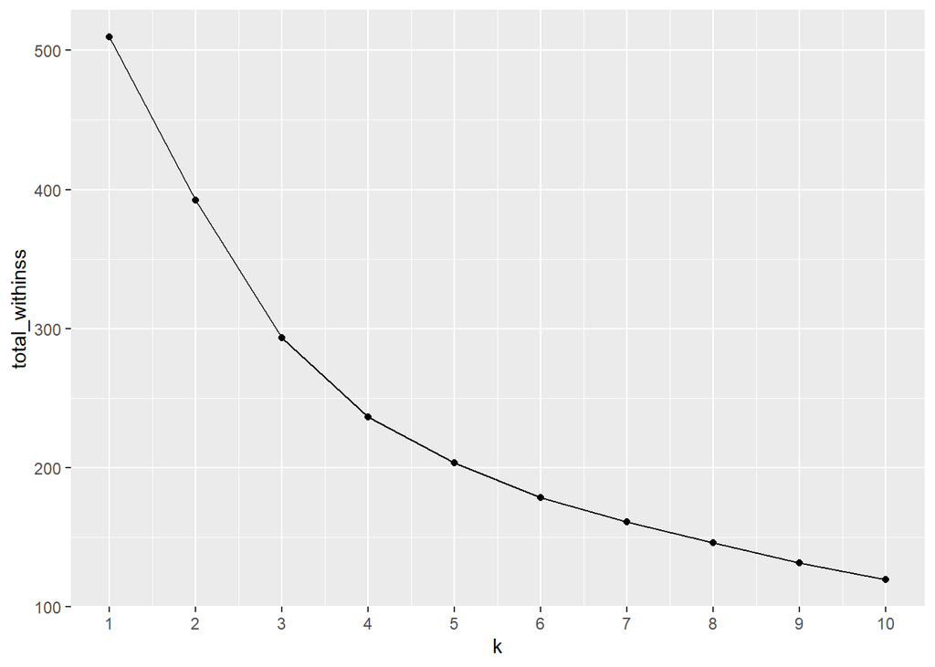

**Podział zbioru na 6 grupy:**

Porównywanie statystyk w grupach (dla k = 6)

```
##
##  Descriptive statistics by group
## group: 1
##              vars  n   mean     sd median trimmed    mad    min    max  range
## Calories        1 20 317.00 112.91 350.00  319.38 103.78 120.00 480.00 360.00
## Fat             2 20  19.05   5.10  19.06   19.21   6.23   8.33  28.05  19.72
## Cholesterol     3 20   0.05   0.02   0.05    0.05   0.03   0.02   0.08   0.06
## Sodium          4 20   0.30   0.10   0.27    0.30   0.11   0.17   0.52   0.35
## Carbohydrate    5 20  51.81   7.92  53.49   51.35   7.76  39.45  73.33  33.88
## Fiber           6 20   1.16   0.98   1.07    1.10   1.48   0.00   3.03   3.03
## Sugars          7 20  28.13  10.39  29.02   28.60  14.44   8.06  41.86  33.80
## Protein         8 20   5.64   2.24   4.88    5.55   1.70   1.67  10.10   8.43
##               skew kurtosis    se
## Calories     -0.33    -1.37 25.25
## Fat          -0.24    -0.94  1.14
## Cholesterol  -0.03    -1.39  0.00
## Sodium        0.67    -0.56  0.02
## Carbohydrate  0.63     0.54  1.77
## Fiber         0.24    -1.25  0.22
## Sugars       -0.28    -1.21  2.32
## Protein       0.43    -0.58  0.50
## ------------------------------------------------------------
## group: 2
##              vars n   mean    sd median trimmed   mad    min    max  range
## Calories        1 8 302.50 51.20 295.00  302.50 44.48 220.00 390.00 170.00
## Fat             2 8   4.03  2.62   3.97    4.03  1.88   1.01   9.38   8.37
## Cholesterol     3 8   0.00  0.00   0.00    0.00  0.00   0.00   0.01   0.01
## Sodium          4 8   0.39  0.13   0.40    0.39  0.09   0.14   0.57   0.43
## Carbohydrate    5 8  51.87  4.46  52.42   51.87  3.73  44.25  58.59  14.34
## Fiber           6 8   3.86  1.62   3.09    3.86  1.25   1.85   6.19   4.34
## Sugars          7 8   9.74  7.90   8.05    9.74  6.13   1.85  25.78  23.93
## Protein         8 8   8.47  2.25   8.71    8.47  2.83   5.47  11.00   5.53
##               skew kurtosis    se
## Calories      0.13    -1.02 18.10
## Fat           0.75    -0.46  0.93
## Cholesterol   0.95    -1.21  0.00
## Sodium       -0.55    -0.56  0.04
## Carbohydrate -0.22    -1.14  1.58
## Fiber         0.30    -1.83  0.57
## Sugars        0.82    -0.65  2.79
```

[output cut: 66 more lines]

```
## Cholesterol     3 14   0.01  0.01   0.01    0.01  0.01  0.00   0.04   0.04
## Sodium          4 14   0.30  0.17   0.38    0.31  0.08  0.03   0.49   0.46
## Carbohydrate    5 14  22.66 12.00  24.57   22.71 15.99  4.29  40.54  36.25
## Fiber           6 14   1.57  1.76   1.40    1.24  0.96  0.00   7.02   7.02
## Sugars          7 14   6.00  6.53   2.70    5.51  1.91  0.00  17.90  17.90
## Protein         8 14   7.56  3.20   8.11    7.60  1.00  1.23  13.46  12.23
##               skew kurtosis    se
## Calories     -0.43    -1.43 17.75
## Fat           0.46    -1.75  1.29
## Cholesterol   0.28    -1.65  0.00
## Sodium       -0.68    -1.38  0.04
## Carbohydrate -0.11    -1.40  3.21
## Fiber         1.98     3.80  0.47
## Sugars        0.84    -1.18  1.75
## Protein      -0.50    -0.20  0.86
```

Na podstawie statystyk w grupach oraz poniższego wykresu można zauważyć, że grupy zostały dokładniej podzielone według zmiennych, które zostały już wskazane we wcześniejszych badaniach. Największe zróżnicowanie miedzy grupami wystękuje pomiędzy zawartością cukru i tłuszczu.

Wykres podziału zbioru na 6 grupy

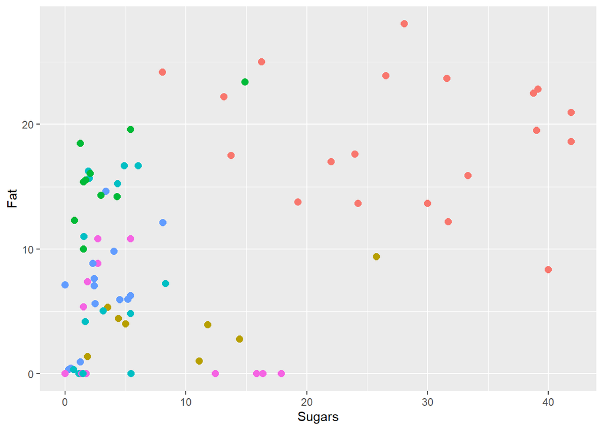

W ofercie występują produkty zawierające bardzo mało cukru i tłuszczu, produkty nie zawierające zbyt dużo cukru, ale za to dużo tłuszczu. Można również wyróżnić grupę, która zawiera istotnie więcej cukru i tłuszczu od pozostałych produktów.  
Menu Starbucks jest podzielone na sześć kategorii wypieki, jogurty, ciepłe śniadania, proteinowe boxy i kanapki. Prawdopodobnie wskazana liczba grup wynika z pogrupowania produktów właśnie w te kategorie. Nie wszystkie produkty zostały przydzielone prawidłowo, ale są takie częściowo odpowiadają swoim kategoriom z menu. Gdyby nie barć pod uwagę podziału z menu, najlepszym pogrupowaniem w kontekście interpretacji jest podział na dwie lub trzy grupy.

## Grupowanie hierarhiczne

#### Wyznaczanie odległości pomiędzy obiektami za pomocą różnych funkcji odległości:

W grupowaniu hierarchicznym zostanie użyty zbiór danych ograniczony o wartości odstające. Zbiór danych został już wcześniej zestandaryzowany.

```r
# obliczanie odległości pomiędzy obiektami za pomocą różnych funkcji odległości
odl_euklidesowa <- dist(dane_st, method = "euclidean")
odl_manhattan <- dist(dane_st, method = "manhattan")
odl_minkowski <- dist(dane_st, method = "minkowski", p=3)
odl_maximum <- dist(dane_st, method = "maximum")
```

#### Podział zbioru na grupy zostanie wykonany w oparciu o metodę Warda i cztery metryki grupowania:

```r
ward_eucliderian <- hclust(odl_euklidesowa, method = "ward.D2")
ward_manhattan <- hclust(odl_manhattan, method = "ward.D2")
ward_minkowski <- hclust(odl_minkowski, method = "ward.D2")
ward_maximum <- hclust(odl_maximum, method = "ward.D2")
```

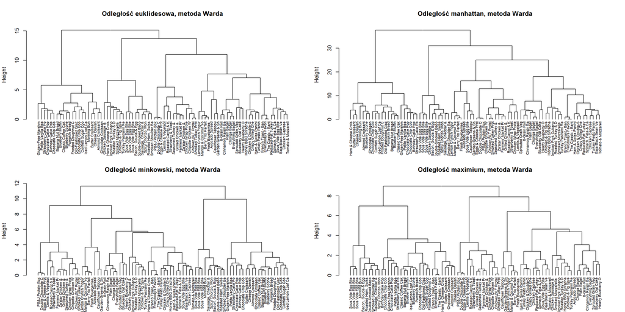

Do dalszej analizy zostanie wykorzystana metoda Warda i metryka euklidesowa.

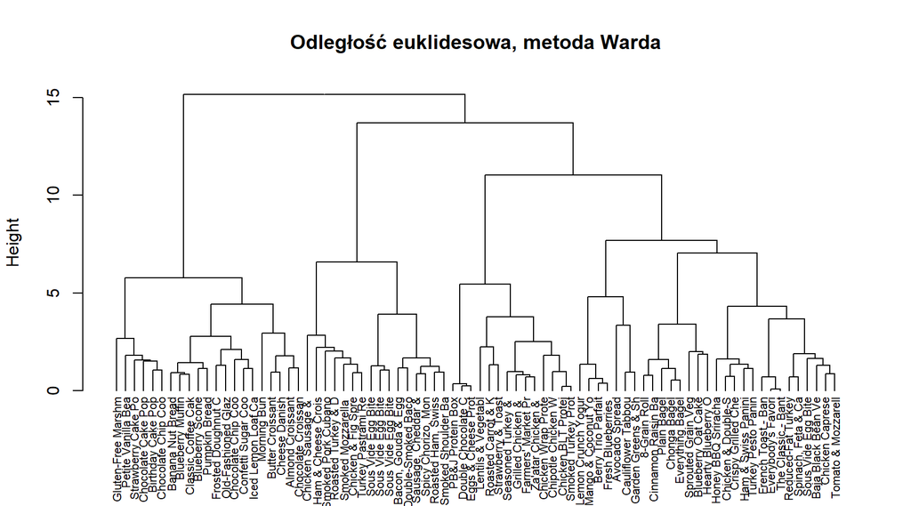

#### Wybór liczby skupień na podstawie analizy wykresu odległości

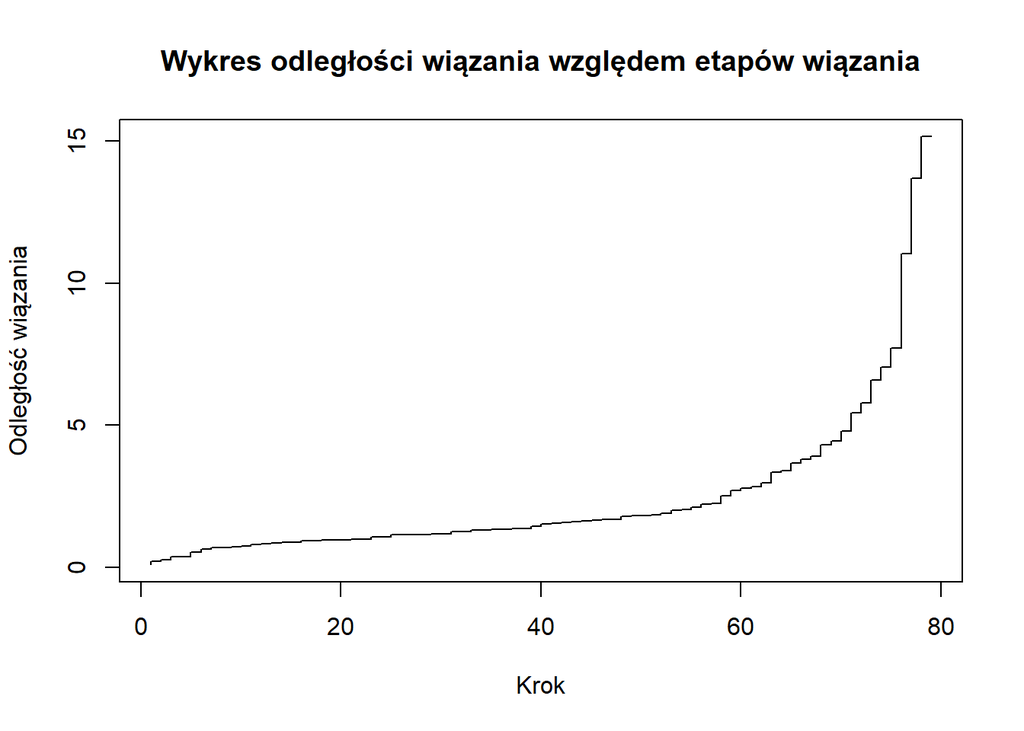

#### Wybór liczby grup na podstawie indeksów ocen klasyfikacji

*index G1* - index Calińskiego i Haravasza  
*index G2* - index Bakóra i Huberta  
*index G3* - index Huberta i Levine’a  
*index S* - index Silhuette

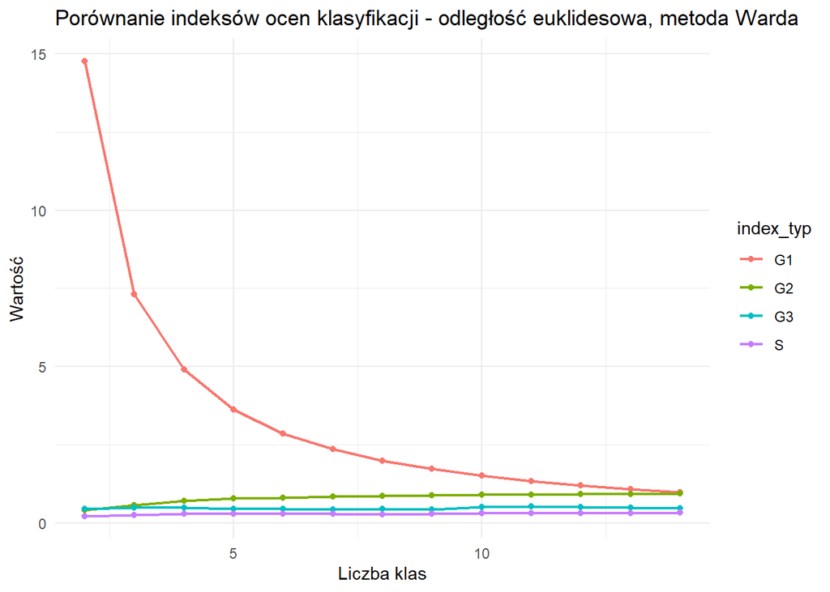

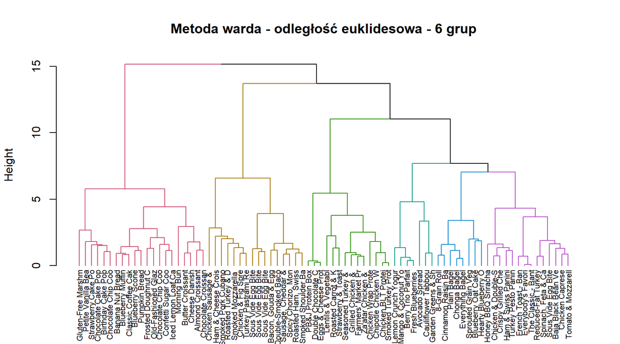

### Prezentacja wyników grupowania za pomocą skalowania wielowymiarowego

#### Rzutowanie obserwacji na przestrzeń dwuwymiarową:

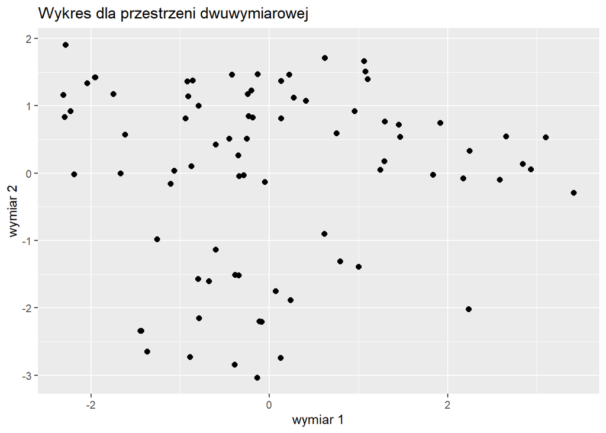

Wartość współczynnika STRESS dla skalowania na przestrzeń dwuwymiarową wynosi 0.329709. Nie jest to dobry wynik i świadczy o bardzo słabym dopasowaniu. Jednym ze sposobów na poprawę dopasowania jest skalowanie na większą liczbę wymiarów. W związku z tym zostanie wykonane skalowanie na przestrzeń trójwymiarową.

#### Rzutowanie obserwacji na przestrzeń trzywymiarową:

Wartość współczynnika STRESS dla skalowania na przestrzeń trzywymiarową wynosi 0.1965738.

Wartość współczynnika uległa poprawie, ale nadal nie jest to wynik, który można uznać za dobry.Dopasowanie jest bardzo słabe. Na wysoką wartość współczynnika może wpływać ilość danych. Waz ze wzrostem ilości obserwacji wartość współczynnika STRESS tez się zwiększa.

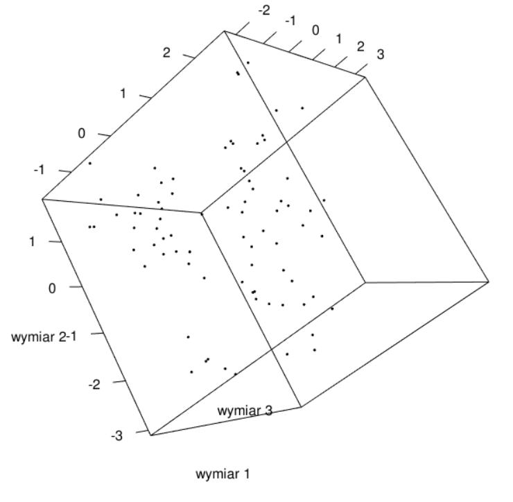

Na powyższym wykresie można zaobserwować wzajemne zależności pomiędzy poszczególnymi produktami. Skalowanie niestety jest słabej jakości i trudno przedstawić jednoznaczne wnioski.

## Podsumowanie

W menu Starbucks znajdują się różnorodne produkty pod względem składu. Można wyodrębnić grupy produktów o wysokiej kaloryczności w stosunku do reszty produktów. Znajdują się też produkty zawierające dużo tłuszczu oraz cukru w stosunku do pozostałych proponowanych przekąsek. Na podstawie grupowania i analizy wielowymiarowej trudno przedstawić dodatkowe wnioski ze względu na to, że składy większości produktów nie różnią się na tyle, aby odległości pomiędzy grupami kształtowały się wyraźnie.